# Risk Factor Analysis

## Outcome Variable

**Outcome Variable:** ever_wasted

## Predictor Variables

**Intervention Variable:** nrooms

**Adjustment Set:**

- arm
- sex
- W_mage
- meducyrs
- feducyrs
- hhwealth_quart
- hfoodsec
- W_mhtcm
- W_nchldlt5
- W_parity
- impfloor
- impsan
- safeh20
- delta_W_mage
- delta_meducyrs
- delta_feducyrs
- delta_hhwealth_quart
- delta_hfoodsec
- delta_W_mhtcm
- delta_W_nchldlt5
- delta_W_parity
- delta_impfloor
- delta_impsan
- delta_safeh20

## Stratifying Variables

The analysis was stratified on these variable(s):

- agecat
- studyid
- country

## Data Summary

| agecat | studyid | country | nrooms | ever_wasted | n_cell | n |
| --- | --- | --- | --- | --- | --- | --- |
| 0-24 months | ki0047075b-MAL-ED | BANGLADESH | 1 | 0 | 92 | 242 |
| 0-24 months | ki0047075b-MAL-ED | BANGLADESH | 1 | 1 | 60 | 242 |
| 0-24 months | ki0047075b-MAL-ED | BANGLADESH | 2 | 0 | 37 | 242 |
| 0-24 months | ki0047075b-MAL-ED | BANGLADESH | 2 | 1 | 13 | 242 |
| 0-24 months | ki0047075b-MAL-ED | BANGLADESH | 3 | 0 | 20 | 242 |
| 0-24 months | ki0047075b-MAL-ED | BANGLADESH | 3 | 1 | 8 | 242 |
| 0-24 months | ki0047075b-MAL-ED | BANGLADESH | 4+ | 0 | 9 | 242 |
| 0-24 months | ki0047075b-MAL-ED | BANGLADESH | 4+ | 1 | 3 | 242 |
| 0-24 months | ki0047075b-MAL-ED | BRAZIL | 1 | 0 | 4 | 210 |
| 0-24 months | ki0047075b-MAL-ED | BRAZIL | 1 | 1 | 0 | 210 |
| 0-24 months | ki0047075b-MAL-ED | BRAZIL | 2 | 0 | 18 | 210 |
| 0-24 months | ki0047075b-MAL-ED | BRAZIL | 2 | 1 | 2 | 210 |
| 0-24 months | ki0047075b-MAL-ED | BRAZIL | 3 | 0 | 55 | 210 |
| 0-24 months | ki0047075b-MAL-ED | BRAZIL | 3 | 1 | 4 | 210 |
| 0-24 months | ki0047075b-MAL-ED | BRAZIL | 4+ | 0 | 114 | 210 |
| 0-24 months | ki0047075b-MAL-ED | BRAZIL | 4+ | 1 | 13 | 210 |
| 0-24 months | ki0047075b-MAL-ED | INDIA | 1 | 0 | 43 | 235 |
| 0-24 months | ki0047075b-MAL-ED | INDIA | 1 | 1 | 41 | 235 |
| 0-24 months | ki0047075b-MAL-ED | INDIA | 2 | 0 | 38 | 235 |
| 0-24 months | ki0047075b-MAL-ED | INDIA | 2 | 1 | 40 | 235 |
| 0-24 months | ki0047075b-MAL-ED | INDIA | 3 | 0 | 25 | 235 |
| 0-24 months | ki0047075b-MAL-ED | INDIA | 3 | 1 | 23 | 235 |
| 0-24 months | ki0047075b-MAL-ED | INDIA | 4+ | 0 | 16 | 235 |
| 0-24 months | ki0047075b-MAL-ED | INDIA | 4+ | 1 | 9 | 235 |
| 0-24 months | ki0047075b-MAL-ED | NEPAL | 1 | 0 | 31 | 236 |
| 0-24 months | ki0047075b-MAL-ED | NEPAL | 1 | 1 | 21 | 236 |
| 0-24 months | ki0047075b-MAL-ED | NEPAL | 2 | 0 | 26 | 236 |
| 0-24 months | ki0047075b-MAL-ED | NEPAL | 2 | 1 | 5 | 236 |
| 0-24 months | ki0047075b-MAL-ED | NEPAL | 3 | 0 | 16 | 236 |
| 0-24 months | ki0047075b-MAL-ED | NEPAL | 3 | 1 | 6 | 236 |

[output cut: 354 more lines]

The following strata were considered:

- agecat: 0-24 months, studyid: ki0047075b-MAL-ED, country: BANGLADESH
- agecat: 0-24 months, studyid: ki0047075b-MAL-ED, country: BRAZIL
- agecat: 0-24 months, studyid: ki0047075b-MAL-ED, country: INDIA
- agecat: 0-24 months, studyid: ki0047075b-MAL-ED, country: NEPAL
- agecat: 0-24 months, studyid: ki0047075b-MAL-ED, country: PERU
- agecat: 0-24 months, studyid: ki0047075b-MAL-ED, country: SOUTH AFRICA
- agecat: 0-24 months, studyid: ki0047075b-MAL-ED, country: TANZANIA, UNITED REPUBLIC OF
- agecat: 0-24 months, studyid: ki1000108-CMC-V-BCS-2002, country: INDIA
- agecat: 0-24 months, studyid: ki1000108-IRC, country: INDIA
- agecat: 0-24 months, studyid: ki1017093b-PROVIDE, country: BANGLADESH
- agecat: 0-24 months, studyid: ki1017093c-NIH-Crypto, country: BANGLADESH
- agecat: 0-24 months, studyid: ki1113344-GMS-Nepal, country: NEPAL
- agecat: 0-24 months, studyid: ki1114097-CONTENT, country: PERU
- agecat: 0-24 months, studyid: ki1135781-COHORTS, country: INDIA
- agecat: 0-24 months, studyid: kiGH5241-JiVitA-3, country: BANGLADESH
- agecat: 0-24 months, studyid: kiGH5241-JiVitA-4, country: BANGLADESH
- agecat: 0-6 months, studyid: ki0047075b-MAL-ED, country: BANGLADESH
- agecat: 0-6 months, studyid: ki0047075b-MAL-ED, country: BRAZIL
- agecat: 0-6 months, studyid: ki0047075b-MAL-ED, country: INDIA
- agecat: 0-6 months, studyid: ki0047075b-MAL-ED, country: NEPAL
- agecat: 0-6 months, studyid: ki0047075b-MAL-ED, country: PERU
- agecat: 0-6 months, studyid: ki0047075b-MAL-ED, country: SOUTH AFRICA
- agecat: 0-6 months, studyid: ki0047075b-MAL-ED, country: TANZANIA, UNITED REPUBLIC OF
- agecat: 0-6 months, studyid: ki1000108-CMC-V-BCS-2002, country: INDIA
- agecat: 0-6 months, studyid: ki1000108-IRC, country: INDIA
- agecat: 0-6 months, studyid: ki1017093b-PROVIDE, country: BANGLADESH
- agecat: 0-6 months, studyid: ki1017093c-NIH-Crypto, country: BANGLADESH
- agecat: 0-6 months, studyid: ki1113344-GMS-Nepal, country: NEPAL
- agecat: 0-6 months, studyid: ki1114097-CONTENT, country: PERU
- agecat: 0-6 months, studyid: ki1135781-COHORTS, country: INDIA
- agecat: 0-6 months, studyid: kiGH5241-JiVitA-3, country: BANGLADESH
- agecat: 0-6 months, studyid: kiGH5241-JiVitA-4, country: BANGLADESH
- agecat: 6-24 months, studyid: ki0047075b-MAL-ED, country: BANGLADESH
- agecat: 6-24 months, studyid: ki0047075b-MAL-ED, country: BRAZIL
- agecat: 6-24 months, studyid: ki0047075b-MAL-ED, country: INDIA
- agecat: 6-24 months, studyid: ki0047075b-MAL-ED, country: NEPAL
- agecat: 6-24 months, studyid: ki0047075b-MAL-ED, country: PERU
- agecat: 6-24 months, studyid: ki0047075b-MAL-ED, country: SOUTH AFRICA
- agecat: 6-24 months, studyid: ki0047075b-MAL-ED, country: TANZANIA, UNITED REPUBLIC OF
- agecat: 6-24 months, studyid: ki1000108-CMC-V-BCS-2002, country: INDIA
- agecat: 6-24 months, studyid: ki1000108-IRC, country: INDIA
- agecat: 6-24 months, studyid: ki1017093b-PROVIDE, country: BANGLADESH
- agecat: 6-24 months, studyid: ki1017093c-NIH-Crypto, country: BANGLADESH
- agecat: 6-24 months, studyid: ki1113344-GMS-Nepal, country: NEPAL
- agecat: 6-24 months, studyid: ki1114097-CONTENT, country: PERU
- agecat: 6-24 months, studyid: ki1135781-COHORTS, country: INDIA
- agecat: 6-24 months, studyid: kiGH5241-JiVitA-3, country: BANGLADESH
- agecat: 6-24 months, studyid: kiGH5241-JiVitA-4, country: BANGLADESH

### Dropped Strata

Some strata were dropped due to rare outcomes:

- agecat: 0-24 months, studyid: ki0047075b-MAL-ED, country: BANGLADESH
- agecat: 0-24 months, studyid: ki0047075b-MAL-ED, country: BRAZIL
- agecat: 0-24 months, studyid: ki0047075b-MAL-ED, country: PERU
- agecat: 0-24 months, studyid: ki0047075b-MAL-ED, country: SOUTH AFRICA
- agecat: 0-24 months, studyid: ki0047075b-MAL-ED, country: TANZANIA, UNITED REPUBLIC OF
- agecat: 0-24 months, studyid: ki1114097-CONTENT, country: PERU
- agecat: 0-6 months, studyid: ki0047075b-MAL-ED, country: BANGLADESH
- agecat: 0-6 months, studyid: ki0047075b-MAL-ED, country: BRAZIL
- agecat: 0-6 months, studyid: ki0047075b-MAL-ED, country: NEPAL
- agecat: 0-6 months, studyid: ki0047075b-MAL-ED, country: PERU
- agecat: 0-6 months, studyid: ki0047075b-MAL-ED, country: SOUTH AFRICA
- agecat: 0-6 months, studyid: ki0047075b-MAL-ED, country: TANZANIA, UNITED REPUBLIC OF
- agecat: 0-6 months, studyid: ki1000108-CMC-V-BCS-2002, country: INDIA
- agecat: 0-6 months, studyid: ki1114097-CONTENT, country: PERU
- agecat: 6-24 months, studyid: ki0047075b-MAL-ED, country: BANGLADESH
- agecat: 6-24 months, studyid: ki0047075b-MAL-ED, country: BRAZIL
- agecat: 6-24 months, studyid: ki0047075b-MAL-ED, country: INDIA
- agecat: 6-24 months, studyid: ki0047075b-MAL-ED, country: NEPAL
- agecat: 6-24 months, studyid: ki0047075b-MAL-ED, country: PERU
- agecat: 6-24 months, studyid: ki0047075b-MAL-ED, country: SOUTH AFRICA
- agecat: 6-24 months, studyid: ki0047075b-MAL-ED, country: TANZANIA, UNITED REPUBLIC OF
- agecat: 6-24 months, studyid: ki1000108-CMC-V-BCS-2002, country: INDIA
- agecat: 6-24 months, studyid: ki1017093b-PROVIDE, country: BANGLADESH
- agecat: 6-24 months, studyid: ki1114097-CONTENT, country: PERU
- agecat: 6-24 months, studyid: ki1135781-COHORTS, country: INDIA

## Methods Detail

We’re interested in the causal parameters $E[Y_a]$ for all values of $a \in \mathcal{A}$. These parameters represent the mean outcome if, possibly contrary to fact, we intervened to set all units to have $A=a$. Under the randomization and positivity assumptions, these are identified by the statistical parameters $\psi_a=E_W[E_{Y|A,W}(Y|A=a,W)]$. In addition, we’re interested in the mean of $Y$, $E[Y]$ under no intervention (the observed mean). We will estimate these parameters by using SuperLearner to fit the relevant likelihood factors – $E_{Y|A,W}(Y|A=a,W)$ and $p(A=a|W)$, and then updating our likelihood fit using a joint TMLE.

For unadjusted analyses ($W=\{\}$), initial likelihoods were estimated using Lrnr_glm to estimate the simple $E(Y|A)$ and Lrnr_mean to estimate $p(A)$. For adjusted analyses, a small library containing Lrnr_glmnet, Lrnr_xgboost, and Lrnr_mean was used.

Having estimated these parameters, we will then use the delta method to estimate relative risks and attributable risks relative to a prespecified baseline level of $A$.

# Results Detail

## Results Plots

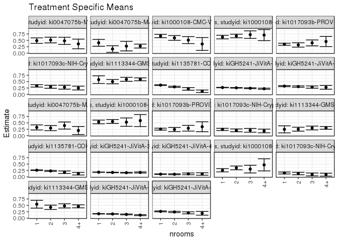

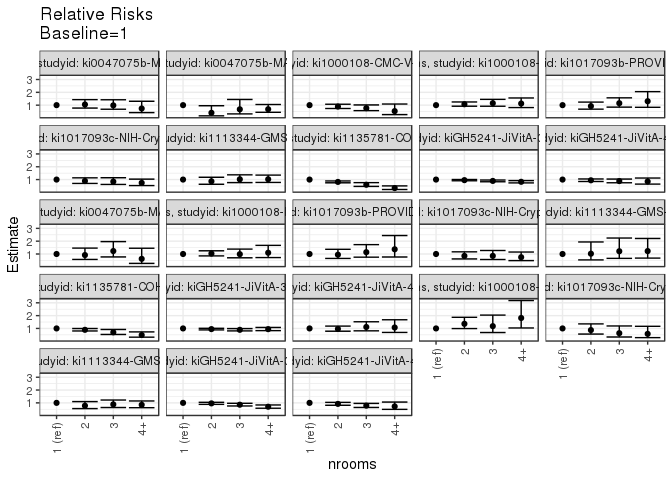

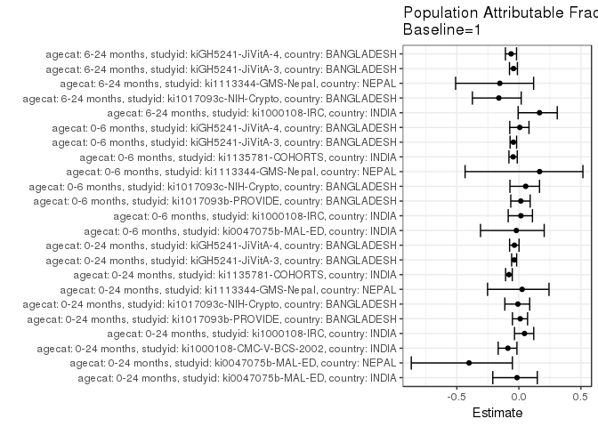

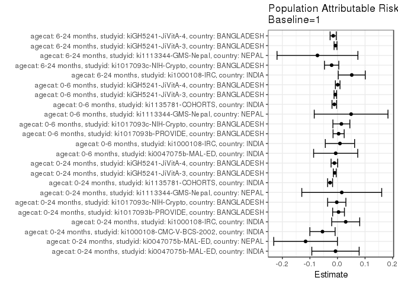

## Results Table

### Parameter: TSM

| agecat | studyid | country | intervention_level | baseline_level | estimate | ci_lower | ci_upper |
| --- | --- | --- | --- | --- | --- | --- | --- |
| 0-24 months | ki0047075b-MAL-ED | INDIA | 1 | NA | 0.4880952 | 0.3809726 | 0.5952179 |
| 0-24 months | ki0047075b-MAL-ED | INDIA | 2 | NA | 0.5128205 | 0.4016591 | 0.6239819 |
| 0-24 months | ki0047075b-MAL-ED | INDIA | 3 | NA | 0.4791667 | 0.3375396 | 0.6207937 |
| 0-24 months | ki0047075b-MAL-ED | INDIA | 4+ | NA | 0.3600000 | 0.1714418 | 0.5485582 |
| 0-24 months | ki0047075b-MAL-ED | NEPAL | 1 | NA | 0.4038462 | 0.2702003 | 0.5374921 |
| 0-24 months | ki0047075b-MAL-ED | NEPAL | 2 | NA | 0.1612903 | 0.0315427 | 0.2910379 |
| 0-24 months | ki0047075b-MAL-ED | NEPAL | 3 | NA | 0.2727273 | 0.0862303 | 0.4592242 |
| 0-24 months | ki0047075b-MAL-ED | NEPAL | 4+ | NA | 0.2748092 | 0.1982008 | 0.3514175 |
| 0-24 months | ki1000108-CMC-V-BCS-2002 | INDIA | 1 | NA | 0.6683168 | 0.6033026 | 0.7333310 |
| 0-24 months | ki1000108-CMC-V-BCS-2002 | INDIA | 2 | NA | 0.5943396 | 0.5007394 | 0.6879398 |
| 0-24 months | ki1000108-CMC-V-BCS-2002 | INDIA | 3 | NA | 0.5098039 | 0.3724211 | 0.6471867 |
| 0-24 months | ki1000108-CMC-V-BCS-2002 | INDIA | 4+ | NA | 0.3571429 | 0.1058123 | 0.6084734 |
| 0-24 months | ki1000108-IRC | INDIA | 1 | NA | 0.6270270 | 0.5572557 | 0.6967983 |
| 0-24 months | ki1000108-IRC | INDIA | 2 | NA | 0.6705882 | 0.5998500 | 0.7413264 |
| 0-24 months | ki1000108-IRC | INDIA | 3 | NA | 0.7222222 | 0.5757302 | 0.8687142 |
| 0-24 months | ki1000108-IRC | INDIA | 4+ | NA | 0.7058824 | 0.4890205 | 0.9227442 |
| 0-24 months | ki1017093b-PROVIDE | BANGLADESH | 1 | NA | 0.3475911 | 0.3060321 | 0.3891501 |
| 0-24 months | ki1017093b-PROVIDE | BANGLADESH | 2 | NA | 0.3203344 | 0.2340757 | 0.4065931 |
| 0-24 months | ki1017093b-PROVIDE | BANGLADESH | 3 | NA | 0.4002834 | 0.2849139 | 0.5156529 |
| 0-24 months | ki1017093b-PROVIDE | BANGLADESH | 4+ | NA | 0.4539273 | 0.2554296 | 0.6524250 |
| 0-24 months | ki1017093c-NIH-Crypto | BANGLADESH | 1 | NA | 0.3337768 | 0.2873208 | 0.3802328 |
| 0-24 months | ki1017093c-NIH-Crypto | BANGLADESH | 2 | NA | 0.2972225 | 0.2379590 | 0.3564860 |
| 0-24 months | ki1017093c-NIH-Crypto | BANGLADESH | 3 | NA | 0.2812621 | 0.2050324 | 0.3574918 |
| 0-24 months | ki1017093c-NIH-Crypto | BANGLADESH | 4+ | NA | 0.2474480 | 0.1727602 | 0.3221358 |
| 0-24 months | ki1113344-GMS-Nepal | NEPAL | 1 | NA | 0.5758703 | 0.4263369 | 0.7254036 |
| 0-24 months | ki1113344-GMS-Nepal | NEPAL | 2 | NA | 0.4980659 | 0.4133212 | 0.5828106 |
| 0-24 months | ki1113344-GMS-Nepal | NEPAL | 3 | NA | 0.5889931 | 0.5111535 | 0.6668327 |
| 0-24 months | ki1113344-GMS-Nepal | NEPAL | 4+ | NA | 0.5896908 | 0.5330521 | 0.6463296 |
| 0-24 months | ki1135781-COHORTS | INDIA | 1 | NA | 0.3622142 | 0.3463766 | 0.3780518 |
| 0-24 months | ki1135781-COHORTS | INDIA | 2 | NA | 0.2960119 | 0.2733834 | 0.3186405 |

[output cut: 62 more lines]

### Parameter: E(Y)

| agecat | studyid | country | intervention_level | baseline_level | estimate | ci_lower | ci_upper |
| --- | --- | --- | --- | --- | --- | --- | --- |
| 0-24 months | ki0047075b-MAL-ED | INDIA | NA | NA | 0.4808511 | 0.4168346 | 0.5448675 |
| 0-24 months | ki0047075b-MAL-ED | NEPAL | NA | NA | 0.2881356 | 0.2302312 | 0.3460400 |
| 0-24 months | ki1000108-CMC-V-BCS-2002 | INDIA | NA | NA | 0.6139410 | 0.5644682 | 0.6634139 |
| 0-24 months | ki1000108-IRC | INDIA | NA | NA | 0.6568627 | 0.6107393 | 0.7029862 |
| 0-24 months | ki1017093b-PROVIDE | BANGLADESH | NA | NA | 0.3514286 | 0.3160364 | 0.3868207 |
| 0-24 months | ki1017093c-NIH-Crypto | BANGLADESH | NA | NA | 0.3311346 | 0.2976093 | 0.3646598 |
| 0-24 months | ki1113344-GMS-Nepal | NEPAL | NA | NA | 0.5913621 | 0.5520608 | 0.6306634 |
| 0-24 months | ki1135781-COHORTS | INDIA | NA | NA | 0.3354454 | 0.3228114 | 0.3480794 |
| 0-24 months | kiGH5241-JiVitA-3 | BANGLADESH | NA | NA | 0.2582060 | 0.2517361 | 0.2646759 |
| 0-24 months | kiGH5241-JiVitA-4 | BANGLADESH | NA | NA | 0.3126363 | 0.2981271 | 0.3271455 |
| 0-6 months | ki0047075b-MAL-ED | INDIA | NA | NA | 0.3148936 | 0.2553821 | 0.3744051 |
| 0-6 months | ki1000108-IRC | INDIA | NA | NA | 0.5441176 | 0.4957312 | 0.5925041 |
| 0-6 months | ki1017093b-PROVIDE | BANGLADESH | NA | NA | 0.2585714 | 0.2261125 | 0.2910304 |
| 0-6 months | ki1017093c-NIH-Crypto | BANGLADESH | NA | NA | 0.2585752 | 0.2273844 | 0.2897660 |
| 0-6 months | ki1113344-GMS-Nepal | NEPAL | NA | NA | 0.2956811 | 0.2591967 | 0.3321655 |
| 0-6 months | ki1135781-COHORTS | INDIA | NA | NA | 0.2494186 | 0.2376119 | 0.2612253 |
| 0-6 months | kiGH5241-JiVitA-3 | BANGLADESH | NA | NA | 0.1763127 | 0.1706830 | 0.1819425 |
| 0-6 months | kiGH5241-JiVitA-4 | BANGLADESH | NA | NA | 0.1078103 | 0.0979895 | 0.1176312 |
| 6-24 months | ki1000108-IRC | INDIA | NA | NA | 0.3112745 | 0.2662918 | 0.3562572 |
| 6-24 months | ki1017093c-NIH-Crypto | BANGLADESH | NA | NA | 0.1315069 | 0.1069744 | 0.1560393 |
| 6-24 months | ki1113344-GMS-Nepal | NEPAL | NA | NA | 0.4728814 | 0.4325613 | 0.5132014 |
| 6-24 months | kiGH5241-JiVitA-3 | BANGLADESH | NA | NA | 0.1638755 | 0.1577484 | 0.1700026 |
| 6-24 months | kiGH5241-JiVitA-4 | BANGLADESH | NA | NA | 0.2479841 | 0.2343635 | 0.2616046 |

### Parameter: RR

| agecat | studyid | country | intervention_level | baseline_level | estimate | ci_lower | ci_upper |
| --- | --- | --- | --- | --- | --- | --- | --- |
| 0-24 months | ki0047075b-MAL-ED | INDIA | 1 | 1 | 1.0000000 | 1.0000000 | 1.0000000 |
| 0-24 months | ki0047075b-MAL-ED | INDIA | 2 | 1 | 1.0506567 | 0.7717801 | 1.4303031 |
| 0-24 months | ki0047075b-MAL-ED | INDIA | 3 | 1 | 0.9817073 | 0.6793598 | 1.4186138 |
| 0-24 months | ki0047075b-MAL-ED | INDIA | 4+ | 1 | 0.7375610 | 0.4179882 | 1.3014629 |
| 0-24 months | ki0047075b-MAL-ED | NEPAL | 1 | 1 | 1.0000000 | 1.0000000 | 1.0000000 |
| 0-24 months | ki0047075b-MAL-ED | NEPAL | 2 | 1 | 0.3993856 | 0.1673490 | 0.9531510 |
| 0-24 months | ki0047075b-MAL-ED | NEPAL | 3 | 1 | 0.6753247 | 0.3159245 | 1.4435834 |
| 0-24 months | ki0047075b-MAL-ED | NEPAL | 4+ | 1 | 0.6804798 | 0.4414650 | 1.0489004 |
| 0-24 months | ki1000108-CMC-V-BCS-2002 | INDIA | 1 | 1 | 1.0000000 | 1.0000000 | 1.0000000 |
| 0-24 months | ki1000108-CMC-V-BCS-2002 | INDIA | 2 | 1 | 0.8893082 | 0.7390273 | 1.0701487 |
| 0-24 months | ki1000108-CMC-V-BCS-2002 | INDIA | 3 | 1 | 0.7628177 | 0.5727883 | 1.0158916 |
| 0-24 months | ki1000108-CMC-V-BCS-2002 | INDIA | 4+ | 1 | 0.5343915 | 0.2626208 | 1.0874016 |
| 0-24 months | ki1000108-IRC | INDIA | 1 | 1 | 1.0000000 | 1.0000000 | 1.0000000 |
| 0-24 months | ki1000108-IRC | INDIA | 2 | 1 | 1.0694726 | 0.9174461 | 1.2466909 |
| 0-24 months | ki1000108-IRC | INDIA | 3 | 1 | 1.1518199 | 0.9139231 | 1.4516420 |
| 0-24 months | ki1000108-IRC | INDIA | 4+ | 1 | 1.1257606 | 0.8119695 | 1.5608184 |
| 0-24 months | ki1017093b-PROVIDE | BANGLADESH | 1 | 1 | 1.0000000 | 1.0000000 | 1.0000000 |
| 0-24 months | ki1017093b-PROVIDE | BANGLADESH | 2 | 1 | 0.9215839 | 0.6869613 | 1.2363389 |
| 0-24 months | ki1017093b-PROVIDE | BANGLADESH | 3 | 1 | 1.1515927 | 0.8441893 | 1.5709340 |
| 0-24 months | ki1017093b-PROVIDE | BANGLADESH | 4+ | 1 | 1.3059231 | 0.8302891 | 2.0540259 |
| 0-24 months | ki1017093c-NIH-Crypto | BANGLADESH | 1 | 1 | 1.0000000 | 1.0000000 | 1.0000000 |
| 0-24 months | ki1017093c-NIH-Crypto | BANGLADESH | 2 | 1 | 0.8904829 | 0.6982064 | 1.1357097 |
| 0-24 months | ki1017093c-NIH-Crypto | BANGLADESH | 3 | 1 | 0.8426653 | 0.6212092 | 1.1430686 |
| 0-24 months | ki1017093c-NIH-Crypto | BANGLADESH | 4+ | 1 | 0.7413577 | 0.5316462 | 1.0337914 |
| 0-24 months | ki1113344-GMS-Nepal | NEPAL | 1 | 1 | 1.0000000 | 1.0000000 | 1.0000000 |
| 0-24 months | ki1113344-GMS-Nepal | NEPAL | 2 | 1 | 0.8648926 | 0.6340671 | 1.1797476 |
| 0-24 months | ki1113344-GMS-Nepal | NEPAL | 3 | 1 | 1.0227878 | 0.7642332 | 1.3688164 |
| 0-24 months | ki1113344-GMS-Nepal | NEPAL | 4+ | 1 | 1.0239994 | 0.7763860 | 1.3505844 |
| 0-24 months | ki1135781-COHORTS | INDIA | 1 | 1 | 1.0000000 | 1.0000000 | 1.0000000 |
| 0-24 months | ki1135781-COHORTS | INDIA | 2 | 1 | 0.8172289 | 0.7483375 | 0.8924624 |

[output cut: 62 more lines]

### Parameter: PAR

| agecat | studyid | country | intervention_level | baseline_level | estimate | ci_lower | ci_upper |
| --- | --- | --- | --- | --- | --- | --- | --- |
| 0-24 months | ki0047075b-MAL-ED | INDIA | 1 | NA | -0.0072442 | -0.0930916 | 0.0786032 |
| 0-24 months | ki0047075b-MAL-ED | NEPAL | 1 | NA | -0.1157106 | -0.2312229 | -0.0001983 |
| 0-24 months | ki1000108-CMC-V-BCS-2002 | INDIA | 1 | NA | -0.0543758 | -0.1001608 | -0.0085908 |
| 0-24 months | ki1000108-IRC | INDIA | 1 | NA | 0.0298357 | -0.0209656 | 0.0806370 |
| 0-24 months | ki1017093b-PROVIDE | BANGLADESH | 1 | NA | 0.0038374 | -0.0175355 | 0.0252103 |
| 0-24 months | ki1017093c-NIH-Crypto | BANGLADESH | 1 | NA | -0.0026422 | -0.0357405 | 0.0304561 |
| 0-24 months | ki1113344-GMS-Nepal | NEPAL | 1 | NA | 0.0154919 | -0.1294230 | 0.1604067 |
| 0-24 months | ki1135781-COHORTS | INDIA | 1 | NA | -0.0267688 | -0.0357752 | -0.0177625 |
| 0-24 months | kiGH5241-JiVitA-3 | BANGLADESH | 1 | NA | -0.0098119 | -0.0150398 | -0.0045840 |
| 0-24 months | kiGH5241-JiVitA-4 | BANGLADESH | 1 | NA | -0.0112349 | -0.0231716 | 0.0007019 |
| 0-6 months | ki0047075b-MAL-ED | INDIA | 1 | NA | -0.0065350 | -0.0865200 | 0.0734501 |
| 0-6 months | ki1000108-IRC | INDIA | 1 | NA | 0.0089825 | -0.0441544 | 0.0621194 |
| 0-6 months | ki1017093b-PROVIDE | BANGLADESH | 1 | NA | 0.0041336 | -0.0160635 | 0.0243306 |
| 0-6 months | ki1017093c-NIH-Crypto | BANGLADESH | 1 | NA | 0.0141477 | -0.0165997 | 0.0448951 |
| 0-6 months | ki1113344-GMS-Nepal | NEPAL | 1 | NA | 0.0494234 | -0.0842523 | 0.1830992 |
| 0-6 months | ki1135781-COHORTS | INDIA | 1 | NA | -0.0114803 | -0.0198429 | -0.0031177 |
| 0-6 months | kiGH5241-JiVitA-3 | BANGLADESH | 1 | NA | -0.0077818 | -0.0124090 | -0.0031546 |
| 0-6 months | kiGH5241-JiVitA-4 | BANGLADESH | 1 | NA | 0.0007592 | -0.0075962 | 0.0091146 |
| 6-24 months | ki1000108-IRC | INDIA | 1 | NA | 0.0518151 | 0.0028666 | 0.1007635 |
| 6-24 months | ki1017093c-NIH-Crypto | BANGLADESH | 1 | NA | -0.0212309 | -0.0471652 | 0.0047034 |
| 6-24 months | ki1113344-GMS-Nepal | NEPAL | 1 | NA | -0.0726100 | -0.2193139 | 0.0740939 |
| 6-24 months | kiGH5241-JiVitA-3 | BANGLADESH | 1 | NA | -0.0070870 | -0.0122910 | -0.0018830 |
| 6-24 months | kiGH5241-JiVitA-4 | BANGLADESH | 1 | NA | -0.0155414 | -0.0267200 | -0.0043627 |

### Parameter: PAF

| agecat | studyid | country | intervention_level | baseline_level | estimate | ci_lower | ci_upper |
| --- | --- | --- | --- | --- | --- | --- | --- |
| 0-24 months | ki0047075b-MAL-ED | INDIA | 1 | NA | -0.0150653 | -0.2102721 | 0.1486562 |
| 0-24 months | ki0047075b-MAL-ED | NEPAL | 1 | NA | -0.4015837 | -0.8671485 | -0.0521053 |
| 0-24 months | ki1000108-CMC-V-BCS-2002 | INDIA | 1 | NA | -0.0885685 | -0.1666538 | -0.0157095 |
| 0-24 months | ki1000108-IRC | INDIA | 1 | NA | 0.0454215 | -0.0353262 | 0.1198716 |
| 0-24 months | ki1017093b-PROVIDE | BANGLADESH | 1 | NA | 0.0109195 | -0.0518307 | 0.0699262 |
| 0-24 months | ki1017093c-NIH-Crypto | BANGLADESH | 1 | NA | -0.0079793 | -0.1130857 | 0.0872021 |
| 0-24 months | ki1113344-GMS-Nepal | NEPAL | 1 | NA | 0.0261969 | -0.2524182 | 0.2428308 |
| 0-24 months | ki1135781-COHORTS | INDIA | 1 | NA | -0.0798008 | -0.1070221 | -0.0532489 |
| 0-24 months | kiGH5241-JiVitA-3 | BANGLADESH | 1 | NA | -0.0380003 | -0.0584822 | -0.0179149 |
| 0-24 months | kiGH5241-JiVitA-4 | BANGLADESH | 1 | NA | -0.0359359 | -0.0747802 | 0.0015045 |
| 0-6 months | ki0047075b-MAL-ED | INDIA | 1 | NA | -0.0207529 | -0.3091538 | 0.2041146 |
| 0-6 months | ki1000108-IRC | INDIA | 1 | NA | 0.0165084 | -0.0861781 | 0.1094870 |
| 0-6 months | ki1017093b-PROVIDE | BANGLADESH | 1 | NA | 0.0159861 | -0.0652990 | 0.0910690 |
| 0-6 months | ki1017093c-NIH-Crypto | BANGLADESH | 1 | NA | 0.0547141 | -0.0719528 | 0.1664134 |
| 0-6 months | ki1113344-GMS-Nepal | NEPAL | 1 | NA | 0.1671512 | -0.4335430 | 0.5161379 |
| 0-6 months | ki1135781-COHORTS | INDIA | 1 | NA | -0.0460282 | -0.0800895 | -0.0130410 |
| 0-6 months | kiGH5241-JiVitA-3 | BANGLADESH | 1 | NA | -0.0441364 | -0.0707391 | -0.0181947 |
| 0-6 months | kiGH5241-JiVitA-4 | BANGLADESH | 1 | NA | 0.0070419 | -0.0735068 | 0.0815468 |
| 6-24 months | ki1000108-IRC | INDIA | 1 | NA | 0.1664609 | -0.0060540 | 0.3093936 |
| 6-24 months | ki1017093c-NIH-Crypto | BANGLADESH | 1 | NA | -0.1614433 | -0.3746120 | 0.0186681 |
| 6-24 months | ki1113344-GMS-Nepal | NEPAL | 1 | NA | -0.1535481 | -0.5099955 | 0.1187568 |
| 6-24 months | kiGH5241-JiVitA-3 | BANGLADESH | 1 | NA | -0.0432461 | -0.0755898 | -0.0118751 |
| 6-24 months | kiGH5241-JiVitA-4 | BANGLADESH | 1 | NA | -0.0626708 | -0.1085129 | -0.0187245 |